# Grad School Admissions Analysis

Bailey Hatcher

I will be looking at and using the GradSchool_Admissions.csv dataset for my analysis.  
First, we need to load in the necessary libraries:

```r
library(tidyverse)
```

```r
library(ggplot2)
library(broom)
library(performance)
```

Now we can load in the data set and take a look at its structure:

```r
dat <- read.csv("../../Data/GradSchool_Admissions.csv")

str(dat)
```

```
## 'data.frame':    400 obs. of  4 variables:
##  $ admit: int  0 1 1 1 0 1 1 0 1 0 ...
##  $ gre  : int  380 660 800 640 520 760 560 400 540 700 ...
##  $ gpa  : num  3.61 3.67 4 3.19 2.93 3 2.98 3.08 3.39 3.92 ...
##  $ rank : int  3 3 1 4 4 2 1 2 3 2 ...
```

The data does not need much cleaning, but rank and admit should be treated as factor instead of integer. It would also be helpful to create a new column called admit_label that tells us whether they got accepted or rejected.

```r
# change columns to factor
dat$rank <- as.factor(dat$rank)
dat$admit <- as.factor(dat$admit)

# create a new column called admit_label
dat <- dat %>%
  mutate(admit_label = ifelse(admit == 1, "accept", "reject"))
```

Because admit is binary (1 = accept, 0 = reject), we should use logistic regression for modeling. Below are the eight models that I decided to build:

```r
# Model 1:
mod1 <- glm(admit ~ gre, data = dat, family = "binomial")

# Model 2:
mod2 <- glm(admit ~ gpa, data = dat, family = "binomial")

# Model 3:
mod3 <- glm(admit ~ rank, data = dat, family = "binomial")

# Model 4:
mod4 <- glm(admit ~ gre + gpa, data = dat, family = "binomial")

# Model 5:
mod5 <- glm(admit ~ gre + gpa + rank, data = dat, family = "binomial")

# Model 6:
mod6 <- glm(admit ~ gre * gpa + rank, data = dat, family = "binomial")

# Model 7:
mod7 <- glm(admit ~ gre + gpa * rank, data = dat, family = "binomial")

# Model 8:
mod8 <- glm(admit ~ gre * rank + gpa, data = dat, family = "binomial")
```

Now we can calculate the predicted probabilities of being accepted based on each model and add those values to the dataset:

```r
dat$pred_1 <- predict(mod1, dat, type = 'response')
dat$pred_2 <- predict(mod2, dat, type = 'response')
dat$pred_3 <- predict(mod3, dat, type = 'response')
dat$pred_4 <- predict(mod4, dat, type = 'response')
dat$pred_5 <- predict(mod5, dat, type = 'response')
dat$pred_6 <- predict(mod6, dat, type = 'response')
dat$pred_7 <- predict(mod7, dat, type = 'response')
dat$pred_8 <- predict(mod8, dat, type = 'response')
```

We can use the compare_performance() function from the performance package to compare the different models. First, we compare the models that include only a single independent variable. From this, we can conclude that rank has the greatest predictive power of acceptance or denial out of the single independent variable models.

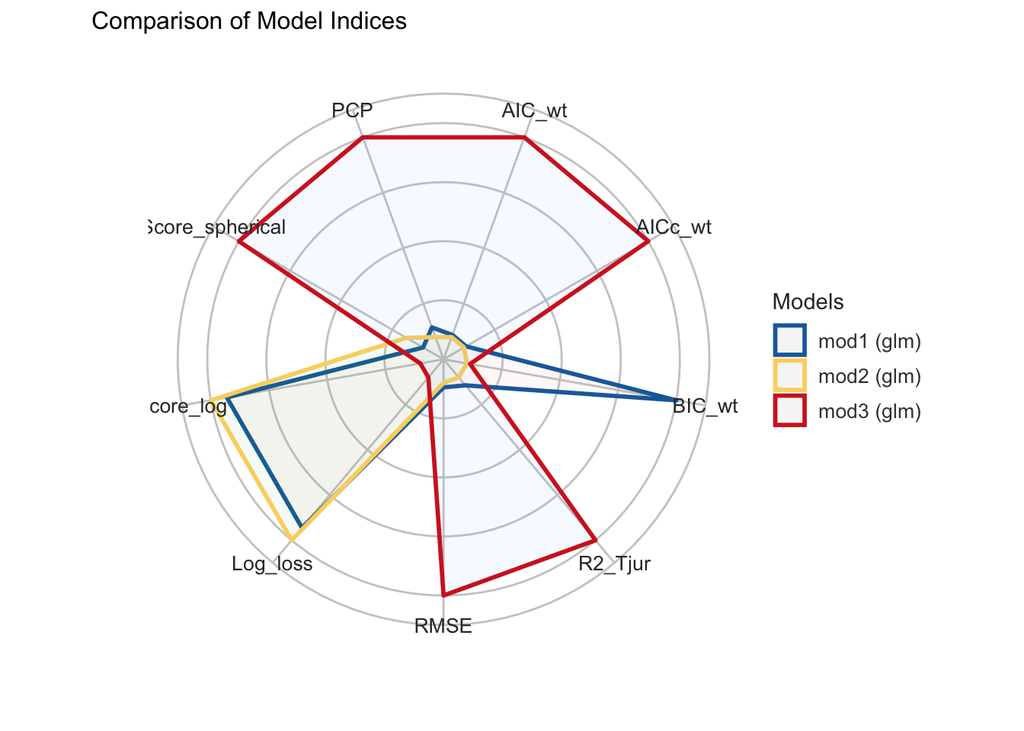

```r
compare_performance(mod1, mod2, mod3) %>% plot()
```

Now we compare the more complex models. From this, we can conclude that model 6 (admit ~ gre * gpa + rank) is the best fit model showing gpa, gre, and rank as the main effects with an interaction between gre and gpa.

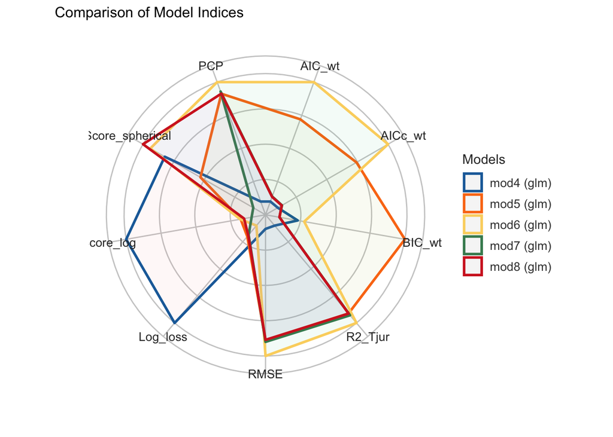

```r
compare_performance(mod4, mod5, mod6, mod7, mod8) %>% plot()
```

To confirm that model 6 is the best fit model, we plot the performance comparisons of every model. This confirms that model 6 is the best fit.

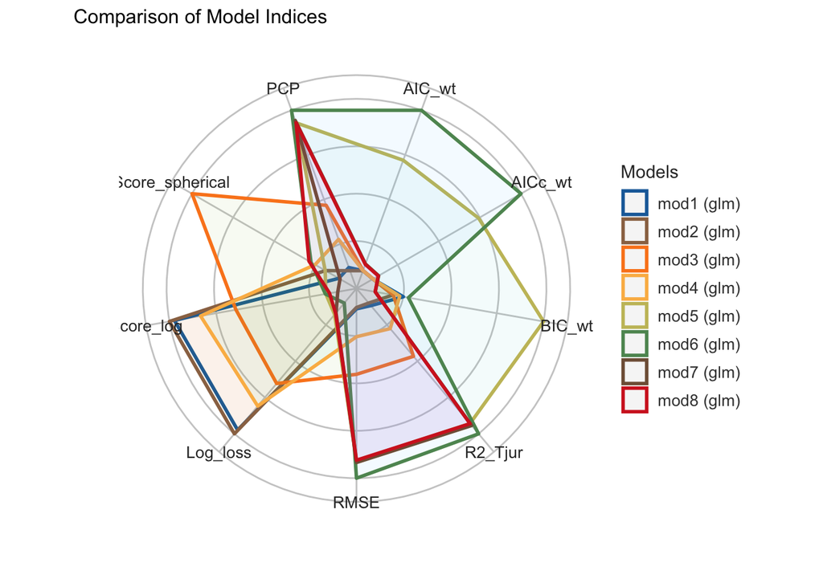

```r
compare_performance(mod1, mod2, mod3, mod4, mod5, mod6, mod7, mod8) %>% plot()
```